# IE360 Homework 1

Fatih Mecidiye

2022-04-04

## INTRODUCTION

In today’s world, as the technology improves, having electrical-electronic goods and computer has become a need more than luxury for people. I wanted to examine the changes in this need by observing the spending on those goods in the homework. Then, I investigated the relationship between the fundamental finance indicators and the increase in expenses on technological devices. So, I used four different data from https://evds2.tcmb.gov.tr/ and https://trends.google.com/trends/ from March 2014 to February 2022.

Data Descriptions:

1: Spending on Electric & Electronic Goods, Computers(Thousand TRY) (“Elektrik-Elektronik Eşya, Bilgisayar(Bin TL)-Düzey”)

2: USD (“(USD) ABD Doları (Döviz Alış)-Düzey”)

3: CPI (“Tüketici Fiyat Endeksi (Genel)-Düzey”)

4: Google Trends Result for Monthly ‘Dizüstü Bilgisayar’ Search

The main motivation for doing this assignment was finding the answer of the questions: “As the years passed, is there a relation between the spending on technological devices and the USD prise, the CPI?” and “Is the increase in the USD price affect the amount of sold technological devices?”. I reviewed the data monthly to find a rough answer to those questions. Also, I plotted these data separately in the sections below.

### Libraries

```r
library(dplyr)
library(readxl)
library(lubridate)
library(RColorBrewer)
library(ggplot2)
library(corrplot)
```

### Data Manipulator Function

The function that manipulates the data for better and easily usage.

```r
DataManipulator = function(a,data){
  k=0
  cellSeq = seq(3, 27, by = 3)
  x = data.frame(Year=NA, Month=NA, a=NA)
  for(i in cellSeq){
    for(j in 1:12){
      k = k+1
      if(i==3){
        x = rbind(x, c((2013 + (i/3)), month.abb[j+2], as.integer(data[k])))
        if(j+2 == 12){
          break
        }
      }
      else if(i==27){
        x = rbind(x, c((2013 + (i/3)), month.abb[j], as.integer(data[k])))
        if(j==2){
          break
        }
      }
      else
        x = rbind(x, c((2013 + (i/3)), month.abb[j], as.integer(data[k])))
    }
  }

  x = x[-1,]
  return(x)
}


my_data = read_excel("EVDS.xlsx")
trends = read_excel("multiTimeline.xlsx")
```

The data comes from the excel files is converted to DataFrame and edited.

```r
my_dataFrame = data.frame(my_data)
trends_dataFrame = data.frame(trends)

my_dataFrame = my_dataFrame[1:96,]
trends_dataFrame <- trends_dataFrame[4:99,]
trends_dataFrame = data.frame(trends_dataFrame)

colnames(my_dataFrame) <- c("Date", "SpentAmount" , "USD", "CPI")
colnames(trends_dataFrame) <- c("# of Dizüstü Bilgisayar Search")

for(i in 1:nrow(trends_dataFrame)) {
  trends_dataFrame[i,] = unlist(strsplit(trends_dataFrame[i,],","))[2]
}
```

The data is prepared for plotting by using DataManipulator function defined above.

```r
SpentAmount = DataManipulator(SpentAmount,my_dataFrame$SpentAmount)
SpentAmount$a[is.na(SpentAmount$a)] = 0
SpentAmount = SpentAmount %>% mutate(Date = ymd(paste(Year, Month, 15)))
SpentAmount = SpentAmount %>% mutate(a = as.numeric(a))
SpentAmount = SpentAmount %>% mutate(Month = match(Month, month.abb))
colnames(SpentAmount) <- c("Year", "Month", "SpentAmount","Date")

USD = DataManipulator(BuyingPrice,my_dataFrame$USD)
USD$a[is.na(USD$a)] = 0
USD = USD %>% mutate(Date = ymd(paste(Year, Month, 15)))
USD = USD %>% mutate(a = as.numeric(a))
USD = USD %>% mutate(Month = match(Month, month.abb))
colnames(USD) <- c("Year", "Month", "USDBuyingPrice","Date")

CPI = DataManipulator(CPI,my_dataFrame$CPI)
CPI$a[is.na(CPI$a)] = 0
CPI = CPI %>% mutate(Date = ymd(paste(Year, Month, 15)))
CPI = CPI %>% mutate(a = as.numeric(a))
CPI = CPI %>% mutate(Month = match(Month, month.abb))
colnames(CPI) <- c("Year", "Month", "CPI","Date")

SearchTrends = DataManipulator(Search,trends_dataFrame$`# of Dizüstü Bilgisayar Search`)
SearchTrends$a[is.na(SearchTrends$a)] = 0
SearchTrends = SearchTrends %>% mutate(Date = ymd(paste(Year, Month, 15)))
SearchTrends = SearchTrends %>% mutate(a = as.numeric(a))
SearchTrends = SearchTrends %>% mutate(Month = match(Month, month.abb))
colnames(SearchTrends) <- c("Year", "Month", "Search","Date")
```

## 1) Monthly Spending on Electric & Electronic Goods, Computers(Thousand TRY) Data of Turkey over 2014-2022

```r
##summary
summary(SpentAmount$SpentAmount)
```

```
##     Min.  1st Qu.   Median     Mean  3rd Qu.     Max.
##  2197482  2878711  3397347  4935445  4783780 17125287
```

```r
## the data from 2014
head(SpentAmount,10)
```

```
##    Year Month SpentAmount       Date
## 2  2014     3     2197482 2014-03-15
## 3  2014     4     2228475 2014-04-15
## 4  2014     5     2850241 2014-05-15
## 5  2014     6     2432895 2014-06-15
## 6  2014     7     2382140 2014-07-15
## 7  2014     8     2895684 2014-08-15
## 8  2014     9     2669685 2014-09-15
## 9  2014    10     3329186 2014-10-15
## 10 2014    11     2732837 2014-11-15
## 11 2014    12     2788562 2014-12-15
```

```r
## the data from the first two months of 2022 and from 2021
tail(SpentAmount,14)
```

```
##    Year Month SpentAmount       Date
## 84 2021     1     9325451 2021-01-15
## 85 2021     2     7699513 2021-02-15
## 86 2021     3     8416650 2021-03-15
## 87 2021     4    10722130 2021-04-15
## 88 2021     5     8845145 2021-05-15
## 89 2021     6     9437957 2021-06-15
## 90 2021     7    11600729 2021-07-15
## 91 2021     8     9816856 2021-08-15
## 92 2021     9    13382441 2021-09-15
## 93 2021    10    13976765 2021-10-15
## 94 2021    11    15932567 2021-11-15
## 95 2021    12    17125287 2021-12-15
## 96 2022     1    11669499 2022-01-15
## 97 2022     2    13879236 2022-02-15
```

### 1.1 Plot of data

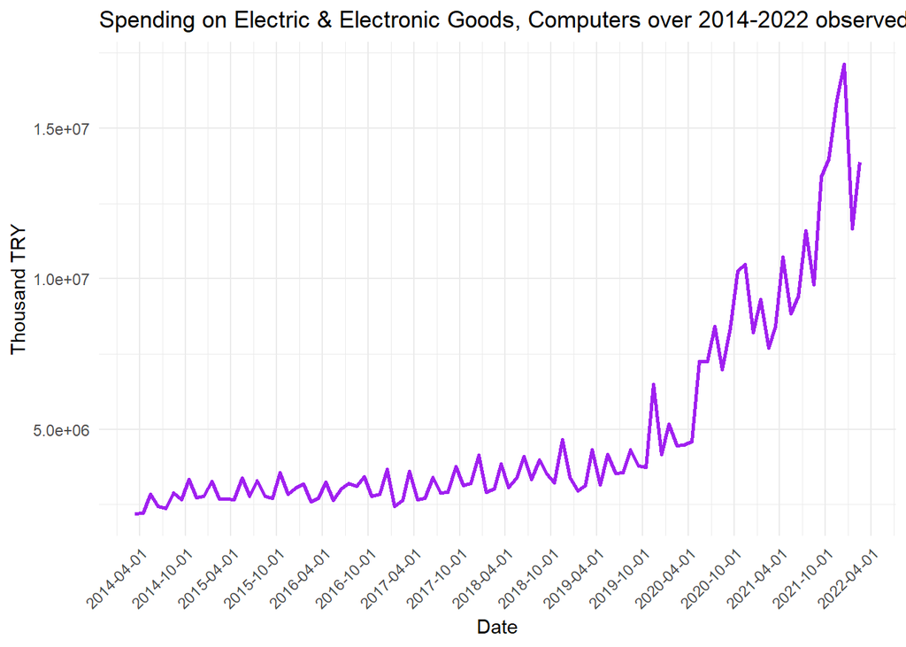

### 1.2 Monthly Plot of Data

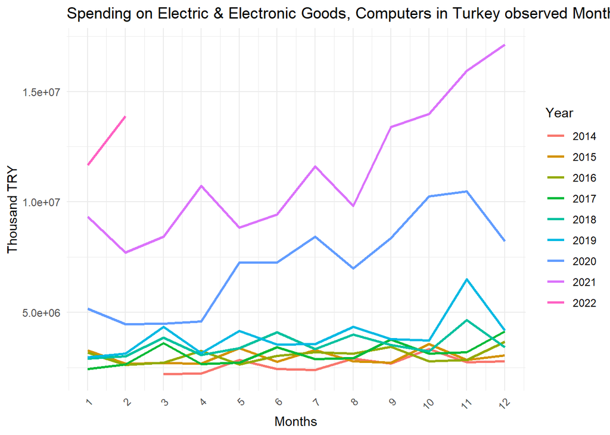

### 1.3 Boxplot of Data

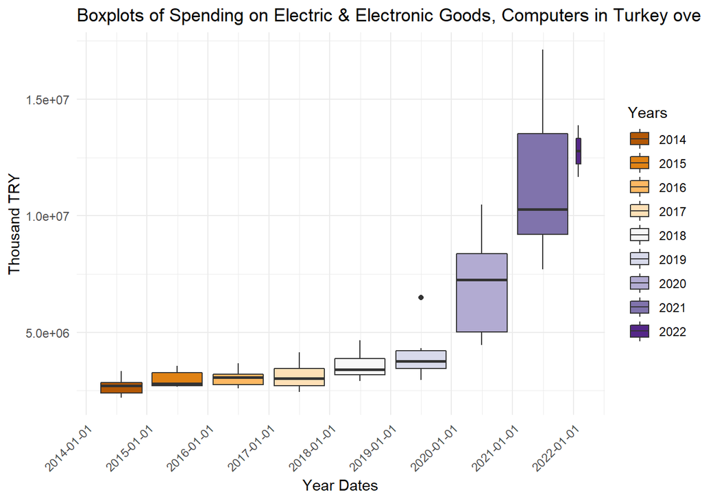

## 2) Monthly USD(Buying) Price Data of Turkey over 2014-2022

```r
## summary
summary(USD$USDBuyingPrice)
```

```
##    Min. 1st Qu.  Median    Mean 3rd Qu.    Max.
##   2.000   2.000   3.000   4.427   6.000  13.000
```

```r
## the data from 2014
head(USD,10)
```

```
##    Year Month USDBuyingPrice       Date
## 2  2014     3              2 2014-03-15
## 3  2014     4              2 2014-04-15
## 4  2014     5              2 2014-05-15
## 5  2014     6              2 2014-06-15
## 6  2014     7              2 2014-07-15
## 7  2014     8              2 2014-08-15
## 8  2014     9              2 2014-09-15
## 9  2014    10              2 2014-10-15
## 10 2014    11              2 2014-11-15
## 11 2014    12              2 2014-12-15
```

```r
## the data from the first two months of 2022 and from 2021
tail(USD,14)
```

```
##    Year Month USDBuyingPrice       Date
## 84 2021     1              7 2021-01-15
## 85 2021     2              7 2021-02-15
## 86 2021     3              7 2021-03-15
## 87 2021     4              8 2021-04-15
## 88 2021     5              8 2021-05-15
## 89 2021     6              8 2021-06-15
## 90 2021     7              8 2021-07-15
## 91 2021     8              8 2021-08-15
## 92 2021     9              8 2021-09-15
## 93 2021    10              9 2021-10-15
## 94 2021    11             10 2021-11-15
## 95 2021    12             13 2021-12-15
## 96 2022     1             13 2022-01-15
## 97 2022     2             13 2022-02-15
```

### 2.1 Plot of data

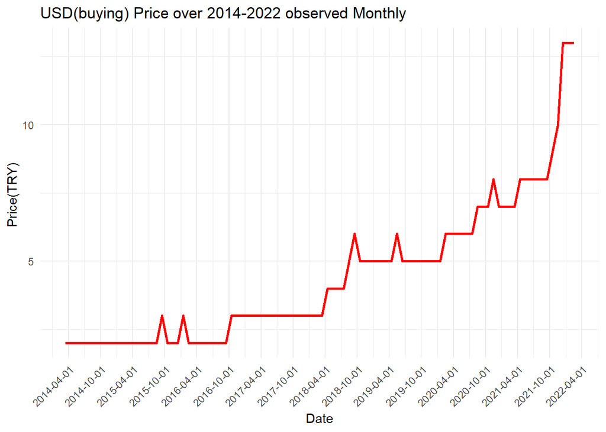

### 2.2 Monthly Plot of Data

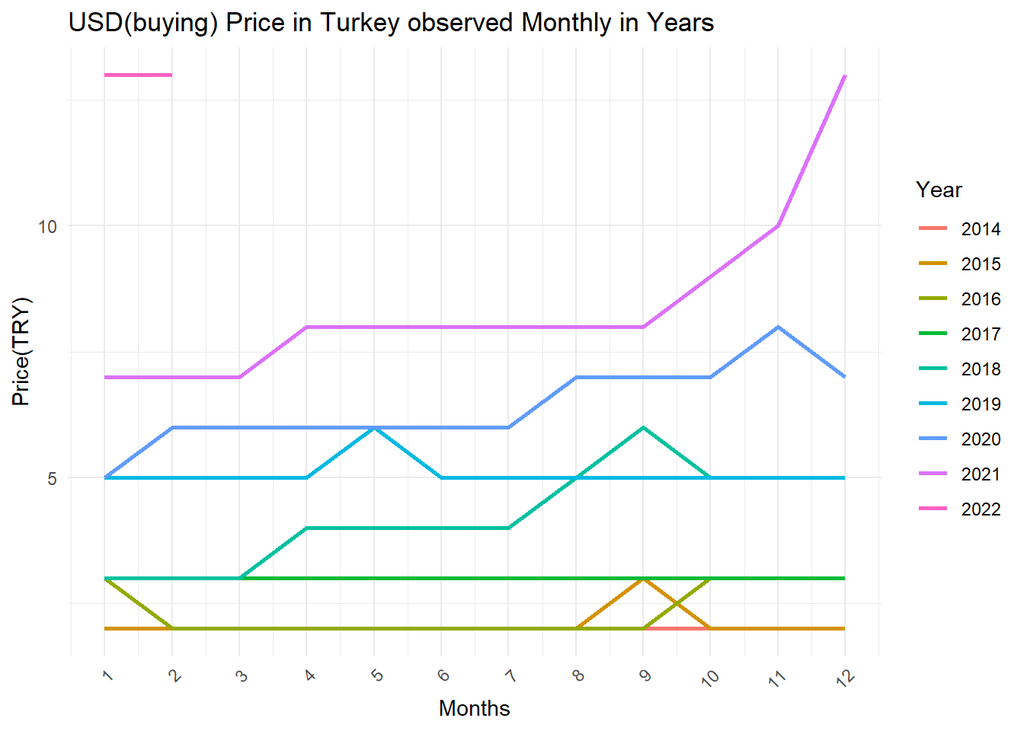

### 2.3 Boxplot of Data

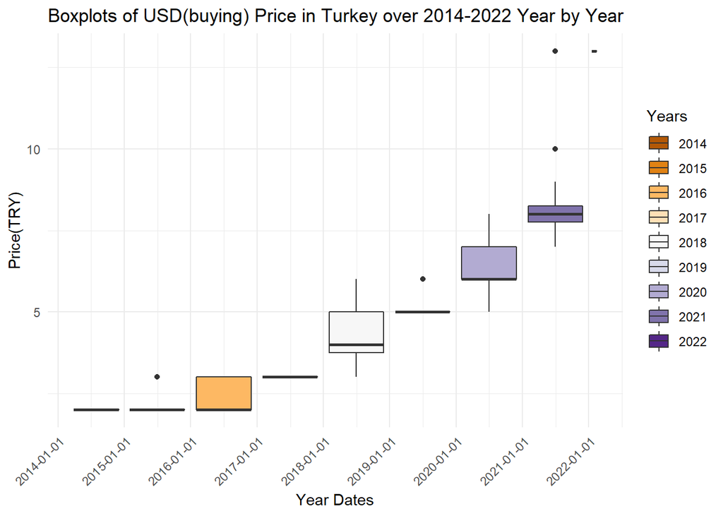

## 3) Monthly CPI Data of Turkey over 2014-2022

```r
## summary
summary(CPI$CPI)
```

```
##    Min. 1st Qu.  Median    Mean 3rd Qu.    Max.
##   237.0   274.0   334.5   374.4   448.5   799.0
```

```r
## the data from 2014
head(CPI,10)
```

```
##    Year Month CPI       Date
## 2  2014     3 237 2014-03-15
## 3  2014     4 240 2014-04-15
## 4  2014     5 241 2014-05-15
## 5  2014     6 242 2014-06-15
## 6  2014     7 243 2014-07-15
## 7  2014     8 243 2014-08-15
## 8  2014     9 243 2014-09-15
## 9  2014    10 248 2014-10-15
## 10 2014    11 248 2014-11-15
## 11 2014    12 247 2014-12-15
```

```r
## the data from the first two months of 2022 and from 2021
tail(CPI,14)
```

```
##    Year Month CPI       Date
## 84 2021     1 513 2021-01-15
## 85 2021     2 517 2021-02-15
## 86 2021     3 523 2021-03-15
## 87 2021     4 532 2021-04-15
## 88 2021     5 537 2021-05-15
## 89 2021     6 547 2021-06-15
## 90 2021     7 557 2021-07-15
## 91 2021     8 563 2021-08-15
## 92 2021     9 570 2021-09-15
## 93 2021    10 584 2021-10-15
## 94 2021    11 604 2021-11-15
## 95 2021    12 686 2021-12-15
## 96 2022     1 763 2022-01-15
## 97 2022     2 799 2022-02-15
```

### 3.1 Plot of Data

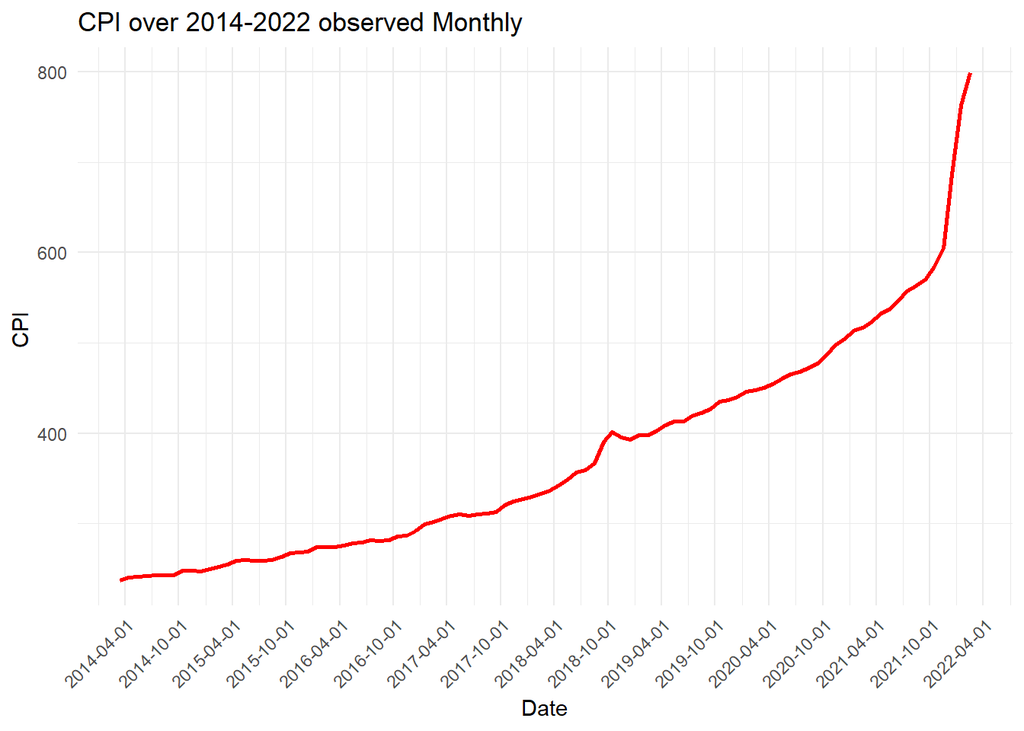

### 3.2 Monthly Plot of Data

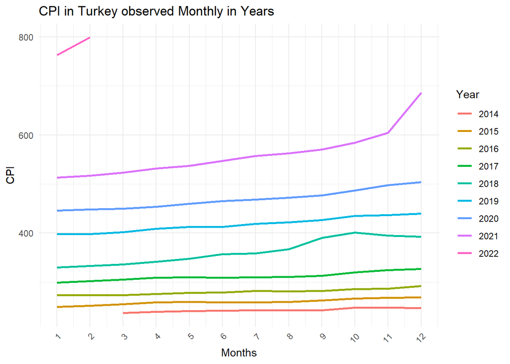

### 3.3 Boxplot of Data

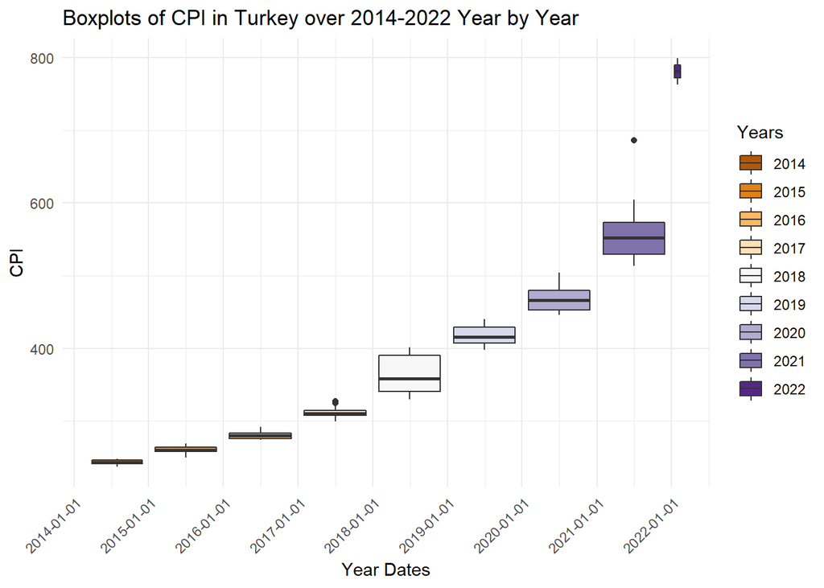

## 4) Google Trends Result for Monthly ‘Dizüstü Bilgisayar’ Search (2014-2022)

```r
## summary
summary(SearchTrends$Search)
```

```
##    Min. 1st Qu.  Median    Mean 3rd Qu.    Max.
##   20.00   28.00   31.00   34.32   36.00  100.00
```

```r
## the data from 2014
head(SearchTrends,10)
```

```
##    Year Month Search       Date
## 2  2014     3     23 2014-03-15
## 3  2014     4     21 2014-04-15
## 4  2014     5     20 2014-05-15
## 5  2014     6     24 2014-06-15
## 6  2014     7     26 2014-07-15
## 7  2014     8     27 2014-08-15
## 8  2014     9     28 2014-09-15
## 9  2014    10     30 2014-10-15
## 10 2014    11     29 2014-11-15
## 11 2014    12     29 2014-12-15
```

```r
## the data from the first two months of 2022 and from 2021
tail(SearchTrends,14)
```

```
##    Year Month Search       Date
## 84 2021     1     52 2021-01-15
## 85 2021     2     48 2021-02-15
## 86 2021     3     41 2021-03-15
## 87 2021     4     37 2021-04-15
## 88 2021     5     36 2021-05-15
## 89 2021     6     31 2021-06-15
## 90 2021     7     28 2021-07-15
## 91 2021     8     35 2021-08-15
## 92 2021     9     39 2021-09-15
## 93 2021    10     36 2021-10-15
## 94 2021    11     34 2021-11-15
## 95 2021    12     29 2021-12-15
## 96 2022     1     32 2022-01-15
## 97 2022     2     32 2022-02-15
```

### 4.1 Plot of Data

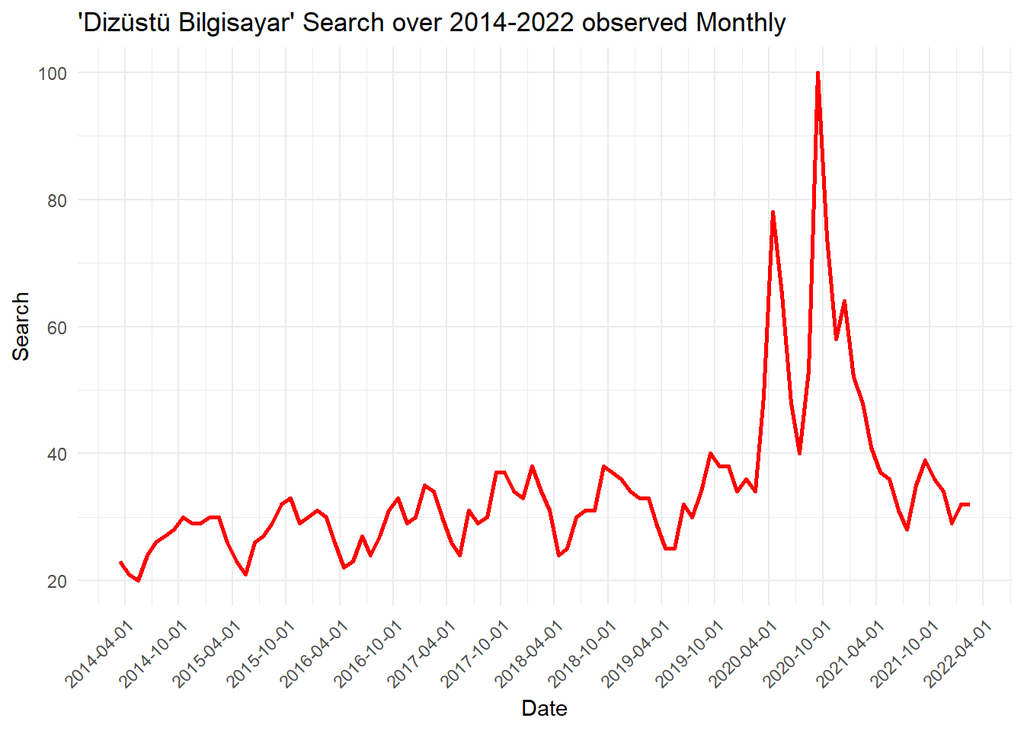

### 4.2 Monthly Plot of Data

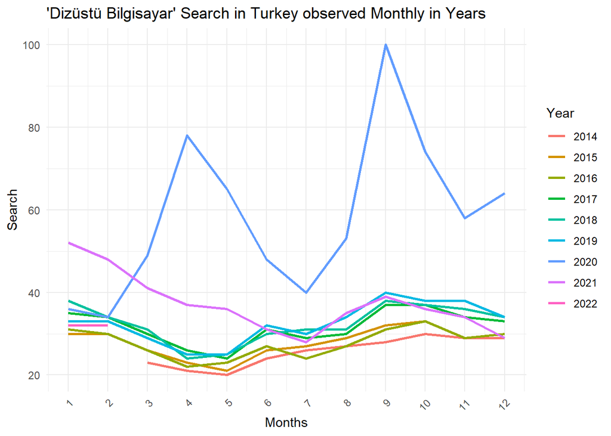

### 4.3 Boxplot of Data

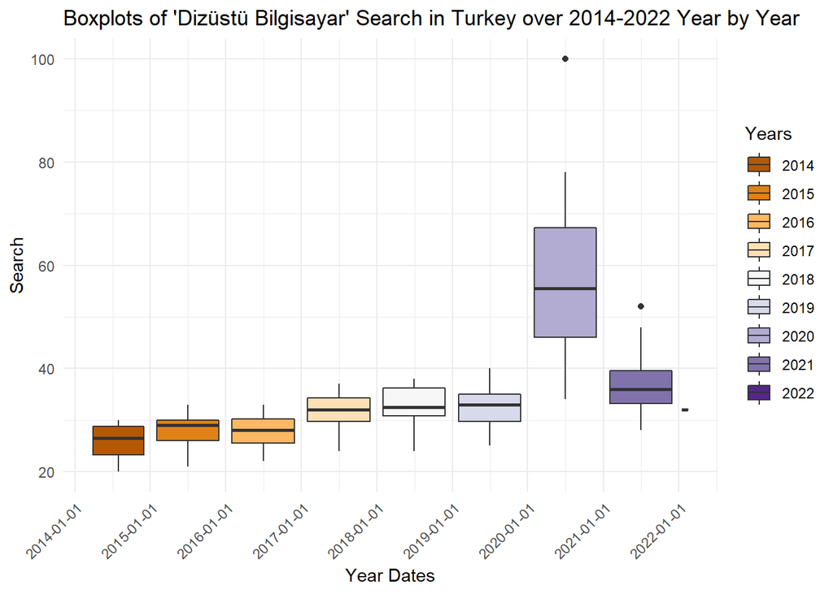

## 5) Correlation Matrix of The Variables

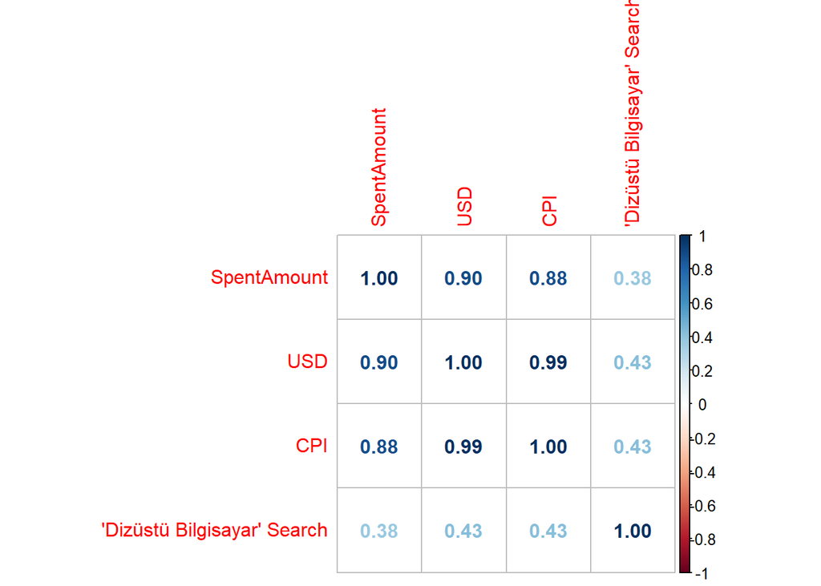

## CONCLUSION

CPI is a measure of the average changes in the prices of a particular set of products and services purchased by a typical consumer. The increases in the exchange rate increase the costs of producers, they are also reflected in the sales price. By considering that relation, it is not surprising that the USD price and the CPI is highly correlated. The graphs in the part 2 and part 3 demonstrate that strong relationship clearly. Also, correlation matrix in the part 5 support the plots.

The price of technological devices increased dramatically over the years as the USD price increases. Additionally, as seen in the section 1, the increase in the total expenditure amount shows similarity with USD price and CPI. That result may show us that the people do not give up the expenses on technological devices. Therefore, we may interpret the situation as Electric & Electronic Goods and Computers became need for human.

In the part 5, the correlation matrix shows that the search trend and the spent amount of money on technological devices is moderately associated.

In conclusion, the results get during the assignment can be used to roughly answer the asked questions at the introduction part. In other words, by the help of used data, the relations between USD price, CPI and the spent money for buying electrical devices can be interpreted.